# Assignment 5

Mark Bruner

11/9/2020

## WHAT MAKES A CEREAL HEALTHY? A RECOMMENDATION

A school wants me to recommend a set of cereals that are healthy. I am using the USDA, FDA, and other reputable sources to determine the attributes of a healthy cereal.I will state my assumptions of what is considered healthy below and will be using those as a guide for determining types of clusters.

**HEALTHY GUIDELINES** * **Sugar content:** .25g of sugar for every 4g of cereal. _(**Reference**: https://www.fns.usda.gov/tn/choose-breakfast-cereals-are-lower-sugar)_

- **Fiber at least 3 grams per serving** (using this reference for this measure since it was more difficult to find a specific number to use.) _(**Reference**: https://foodcorps.org/cms/assets/uploads/2018/01/Healthy-School-Program-Resource-Guide-1-11.pdf)_
- **Sodium content:**
  - Low sodium: 5% or less per serving size
  - High sodium: 20% or more per serving size _(**Reference**: https://www.fda.gov/food/nutrition-education-resources-materials/sodium-your-diet)_

**NOTE** I do not include fat content because fat can be healthy. Since the type of fats are not included I am not going to use that as a factor for healthy or unhealthy. Also, vitamins are listed together and not separately so it is harder to determine healthy levels/types. In addition, many cereals add vitamins to the cereals but are high in sugar so probably not a great measure. Lastly, if the cereal has no vitamins that could be helpful but I think the above measures are better for evaluating healthy cereals from unhealthy.

These guidelines may change as I inspect the clusters and data but these initial guides are a helpful foundation.

```r
# List of packages used for this project.
library(tidyverse)
library(caret)
library(factoextra)
library(cluster)
library(fpc)
library(fastDummies)
set.seed(15)
```

```r
# Changed the column types to better represent the types in the variables.
cereal <- read_csv("Cereals.csv", col_types = c("cffiiiiddiiifddd"))
```

```r
# Looking at the overall structure of the dataset and for any variables needing to be renamed, reclassified, or one hot encoded.
head(cereal)
```

```
## # A tibble: 6 x 16
##   name  mfr   type  calories protein   fat sodium fiber carbo sugars potass
##   <chr> <fct> <fct>    <int>   <int> <int>  <int> <dbl> <dbl>  <int>  <int>
## 1 100%… N     C           70       4     1    130  10     5        6    280
## 2 100%… Q     C          120       3     5     15   2     8        8    135
## 3 All-… K     C           70       4     1    260   9     7        5    320
## 4 All-… K     C           50       4     0    140  14     8        0    330
## 5 Almo… R     C          110       2     2    200   1    14        8     NA
## 6 Appl… G     C          110       2     2    180   1.5  10.5     10     70
## # … with 5 more variables: vitamins <int>, shelf <fct>, weight <dbl>,
## #   cups <dbl>, rating <dbl>
```

```r
tail(cereal)
```

```
## # A tibble: 6 x 16
##   name  mfr   type  calories protein   fat sodium fiber carbo sugars potass
##   <chr> <fct> <fct>    <int>   <int> <int>  <int> <dbl> <dbl>  <int>  <int>
## 1 Tota… G     C          100       3     1    200     3    16      3    110
## 2 Trip… G     C          110       2     1    250     0    21      3     60
## 3 Trix  G     C          110       1     1    140     0    13     12     25
## 4 Whea… R     C          100       3     1    230     3    17      3    115
## 5 Whea… G     C          100       3     1    200     3    17      3    110
## 6 Whea… G     C          110       2     1    200     1    16      8     60
## # … with 5 more variables: vitamins <int>, shelf <fct>, weight <dbl>,
## #   cups <dbl>, rating <dbl>
```

```r
str(cereal)
```

```
## tibble [77 × 16] (S3: spec_tbl_df/tbl_df/tbl/data.frame)
##  $ name    : chr [1:77] "100%_Bran" "100%_Natural_Bran" "All-Bran" "All-Bran_with_Extra_Fiber" ...
##  $ mfr     : Factor w/ 7 levels "N","Q","K","R",..: 1 2 3 3 4 5 3 5 4 6 ...
##  $ type    : Factor w/ 2 levels "C","H": 1 1 1 1 1 1 1 1 1 1 ...
##  $ calories: int [1:77] 70 120 70 50 110 110 110 130 90 90 ...
##  $ protein : int [1:77] 4 3 4 4 2 2 2 3 2 3 ...
##  $ fat     : int [1:77] 1 5 1 0 2 2 0 2 1 0 ...
##  $ sodium  : int [1:77] 130 15 260 140 200 180 125 210 200 210 ...
##  $ fiber   : num [1:77] 10 2 9 14 1 1.5 1 2 4 5 ...
##  $ carbo   : num [1:77] 5 8 7 8 14 10.5 11 18 15 13 ...
##  $ sugars  : int [1:77] 6 8 5 0 8 10 14 8 6 5 ...
##  $ potass  : int [1:77] 280 135 320 330 NA 70 30 100 125 190 ...
##  $ vitamins: int [1:77] 25 0 25 25 25 25 25 25 25 25 ...
##  $ shelf   : Factor w/ 3 levels "3","1","2": 1 1 1 1 1 2 3 1 2 1 ...
##  $ weight  : num [1:77] 1 1 1 1 1 1 1 1.33 1 1 ...
##  $ cups    : num [1:77] 0.33 1 0.33 0.5 0.75 0.75 1 0.75 0.67 0.67 ...
##  $ rating  : num [1:77] 68.4 34 59.4 93.7 34.4 ...
##  - attr(*, "spec")=
##   .. cols(
##   ..   name = col_character(),
##   ..   mfr = col_factor(levels = NULL, ordered = FALSE, include_na = FALSE),
##   ..   type = col_factor(levels = NULL, ordered = FALSE, include_na = FALSE),
##   ..   calories = col_integer(),
##   ..   protein = col_integer(),
##   ..   fat = col_integer(),
##   ..   sodium = col_integer(),
##   ..   fiber = col_double(),
##   ..   carbo = col_double(),
##   ..   sugars = col_integer(),
##   ..   potass = col_integer(),
##   ..   vitamins = col_integer(),
##   ..   shelf = col_factor(levels = NULL, ordered = FALSE, include_na = FALSE),
##   ..   weight = col_double(),
##   ..   cups = col_double(),
##   ..   rating = col_double()
##   .. )
```

```r
# Determining any missing values and in which columns they are located.
colMeans(is.na(cereal))
```

```
##       name        mfr       type   calories    protein        fat     sodium
## 0.00000000 0.00000000 0.00000000 0.00000000 0.00000000 0.00000000 0.00000000
##      fiber      carbo     sugars     potass   vitamins      shelf     weight
## 0.00000000 0.01298701 0.01298701 0.02597403 0.00000000 0.00000000 0.00000000
##       cups     rating
## 0.00000000 0.00000000
```

Carbo, sugars, and potass are the only variables with missing values. It makes the most sense to simply remove them since it will only be about 3 cereals (rows). Also, noticed that the data for weight measurement is mixed. Going to convert the weight measurement to grams as well as the cups column. Using 201.6g per cup and 453.6g per lbs (it seems that the weight column is in lbs.). Normalizing will remove these measurements but I will need to compare clusters later, pre-normalization, so this conversion will help me later. Also, the USDA has different levels for healthy amounts of sugars depending on the serving size in grams.

```r
# Converted cups/weights to grams.
cereal %>%
  mutate(cups = cups * 201.6, weight = weight * 453.6) %>%
  rename(serving_size = cups) -> cereal
```

### Normalizing Dataset

```r
# normalized the dataset before removing rows with missing values so I can use the values in those rows to help get closer to the "true" mean and variance.
norm <- preProcess(cereal, method = "scale", "center")
```

```r
# Removed the rows with missing values.
complete <- cereal[complete.cases(cereal), ]
colMeans(is.na(complete))
```

```
##         name          mfr         type     calories      protein          fat
##            0            0            0            0            0            0
##       sodium        fiber        carbo       sugars       potass     vitamins
##            0            0            0            0            0            0
##        shelf       weight serving_size       rating
##            0            0            0            0
```

```r
# One hot encoding of "type" and "shelf" variables.
complete <- dummy_cols(complete, select_columns = c("type", "shelf"), remove_first_dummy = FALSE, remove_selected_columns = TRUE)
```

```r
# Normalizing compete df.
norm <- preProcess(complete, method = c("scale", "center"))
complete <- predict(norm, complete)
summary(complete)
```

```
##      name           mfr       calories          protein
##  Length:74          N: 5   Min.   :-2.8738   Min.   :-1.40687
##  Class :character   Q: 7   1st Qu.:-0.3541   1st Qu.:-0.47733
##  Mode  :character   K:23   Median : 0.1498   Median :-0.01256
##                     R: 7   Mean   : 0.0000   Mean   : 0.00000
##                     G:22   3rd Qu.: 0.1498   3rd Qu.: 0.45221
##                     P: 9   Max.   : 2.6695   Max.   : 3.24083
##                     A: 1
##       fat              sodium            fiber              carbo
##  Min.   :-0.9932   Min.   :-1.9616   Min.   :-0.89778   Min.   :-2.50014
##  1st Qu.:-0.9932   1st Qu.:-0.3306   1st Qu.:-0.79462   1st Qu.:-0.70143
##  Median : 0.0000   Median : 0.2131   Median :-0.07249   Median :-0.05903
##  Mean   : 0.0000   Mean   : 0.0000   Mean   : 0.00000   Mean   : 0.00000
##  3rd Qu.: 0.0000   3rd Qu.: 0.6661   3rd Qu.: 0.34015   3rd Qu.: 0.58337
##  Max.   : 3.9729   Max.   : 1.9045   Max.   : 4.87925   Max.   : 2.12512
##
##      sugars            potass           vitamins           weight
##  Min.   :-1.6306   Min.   :-1.1783   Min.   :-1.3032   Min.   :-3.4600
##  1st Qu.:-0.9424   1st Qu.:-0.8079   1st Qu.:-0.1818   1st Qu.:-0.2008
##  Median :-0.0248   Median :-0.1201   Median :-0.1818   Median :-0.2008
##  Mean   : 0.0000   Mean   : 0.0000   Mean   : 0.0000   Mean   : 0.0000
##  3rd Qu.: 0.8928   3rd Qu.: 0.3031   3rd Qu.:-0.1818   3rd Qu.:-0.2008
##  Max.   : 1.8104   Max.   : 3.2660   Max.   : 3.1822   Max.   : 3.0583
##
##   serving_size         rating            type_C            type_H
##  Min.   :-2.4251   Min.   :-1.7336   Min.   :-8.4861   Min.   :-0.1162
##  1st Qu.:-0.6432   1st Qu.:-0.7071   1st Qu.: 0.1162   1st Qu.:-0.1162
##  Median :-0.3038   Median :-0.1510   Median : 0.1162   Median :-0.1162
##  Mean   : 0.0000   Mean   : 0.0000   Mean   : 0.0000   Mean   : 0.0000
##  3rd Qu.: 0.7568   3rd Qu.: 0.5807   3rd Qu.: 0.1162   3rd Qu.:-0.1162
##  Max.   : 2.8780   Max.   : 3.6578   Max.   : 0.1162   Max.   : 8.4861
##
##     shelf_3           shelf_1           shelf_2
##  Min.   :-0.9409   Min.   :-0.5838   Min.   :-0.6045
##  1st Qu.:-0.9409   1st Qu.:-0.5838   1st Qu.:-0.6045
##  Median :-0.9409   Median :-0.5838   Median :-0.6045
##  Mean   : 0.0000   Mean   : 0.0000   Mean   : 0.0000
##  3rd Qu.: 1.0484   3rd Qu.: 1.1215   3rd Qu.: 1.6320
##  Max.   : 1.0484   Max.   : 1.6899   Max.   : 1.6320
##
```

```r
row.names(complete) <- complete$name
d <- dist(complete, method = "euclidean")
```

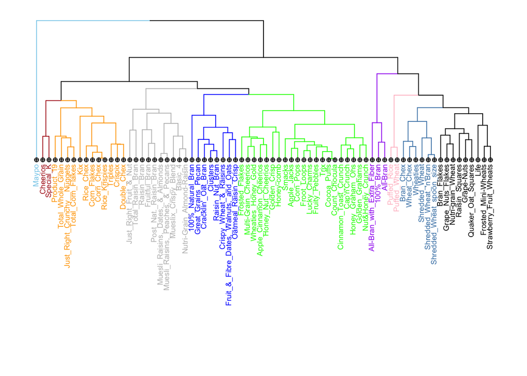

```r
# Hierarchical clustering using Complete Linkage, Single Linkage, Average Linkage, and Ward. Using agnes() to obtain the AC or cluster structure strength and using hclust() to plot dendrogram.
library(dendextend)
divisive <- diana(d, as.matrix(d),
                  diss = TRUE, keep.diss = TRUE)
hc_comp <- hclust(d, method = "complete")
dend_comp <- as.dendrogram(hc_comp)

par(mar=c(14,1,1,1))
dend_comp %>%
  set("labels_col", value = c("skyblue","firebrick", "orange", "grey", "blue", "green", "purple", "pink", "steelblue", "black"), k=10) %>%
  set("branches_k_color", value = c("skyblue","firebrick", "orange", "grey", "blue", "green", "purple", "pink", "steelblue", "black"), k = 10) %>%
  set("leaves_pch", 10)  %>%
  set("nodes_cex", 0.7) %>%
  set("labels_cex", .6) %>%
  plot(axes=FALSE)
```

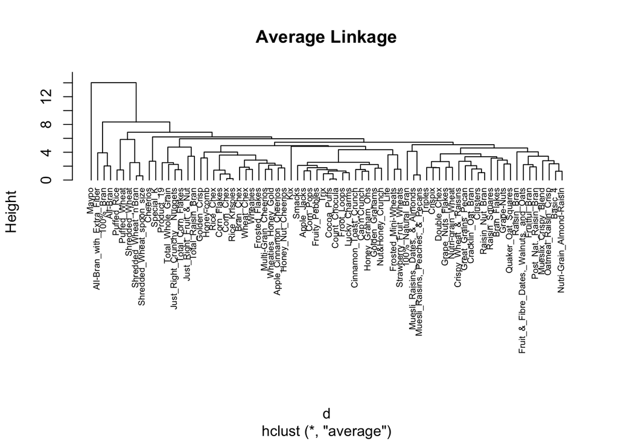

```r
# Plotting each of the HC to see what their dendrograms look like so I can make a better determination of cluster numbers.
hc_ave <- hclust(d, method = "average")
hc_single <- hclust(d, method = "single")
hc_ward <- hclust(d, method = "ward.D2")

plot(hc_ave, cex = 0.6, hang = -1, main = "Average Linkage")
```

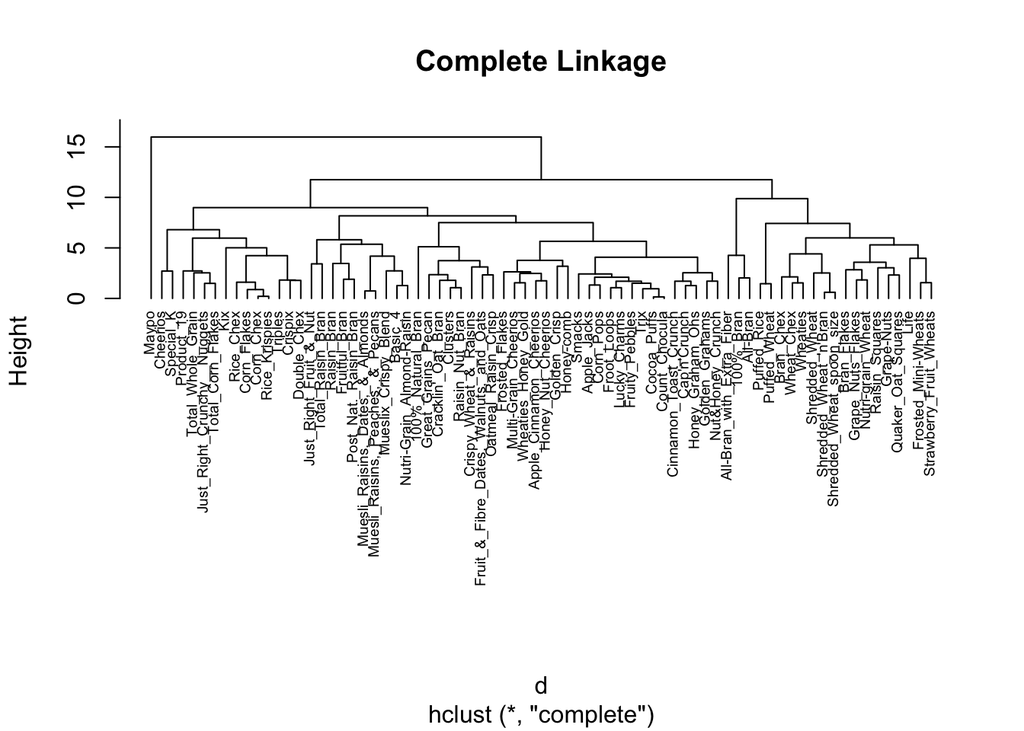

```r
plot(hc_comp, cex = 0.6, hang = -1, main = "Complete Linkage")
```

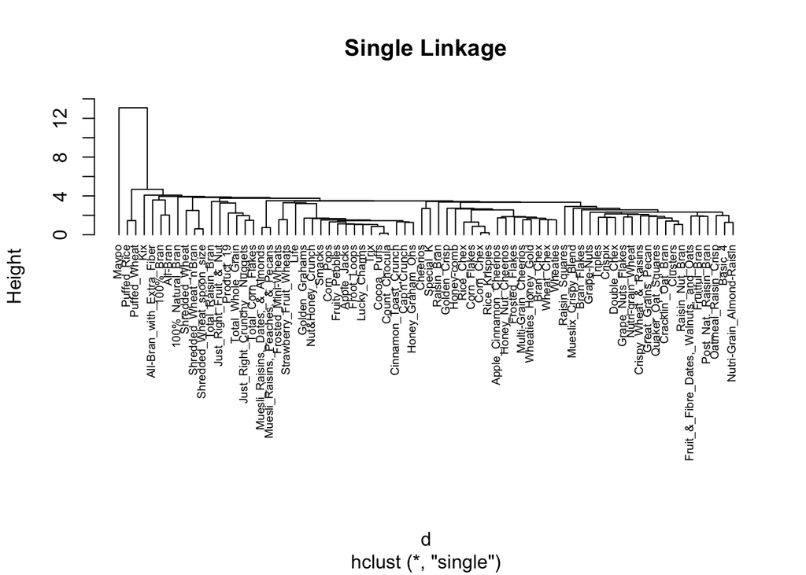

```r
plot(hc_single, cex = 0.6, hang = -1, main = "Single Linkage")
```

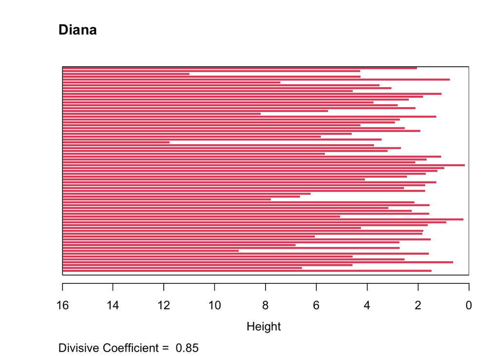

[figure not shown]

```r
plot(divisive, main = "Diana")
```

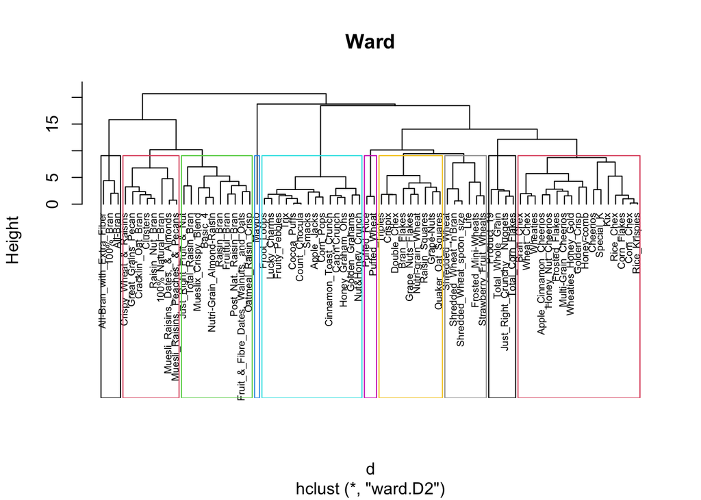

```r
plot(hc_ward, cex = 0.6, hang = -.9, main = "Ward")
cluster <- rect.hclust(hc_ward, h = 9, border = 1:10)
```

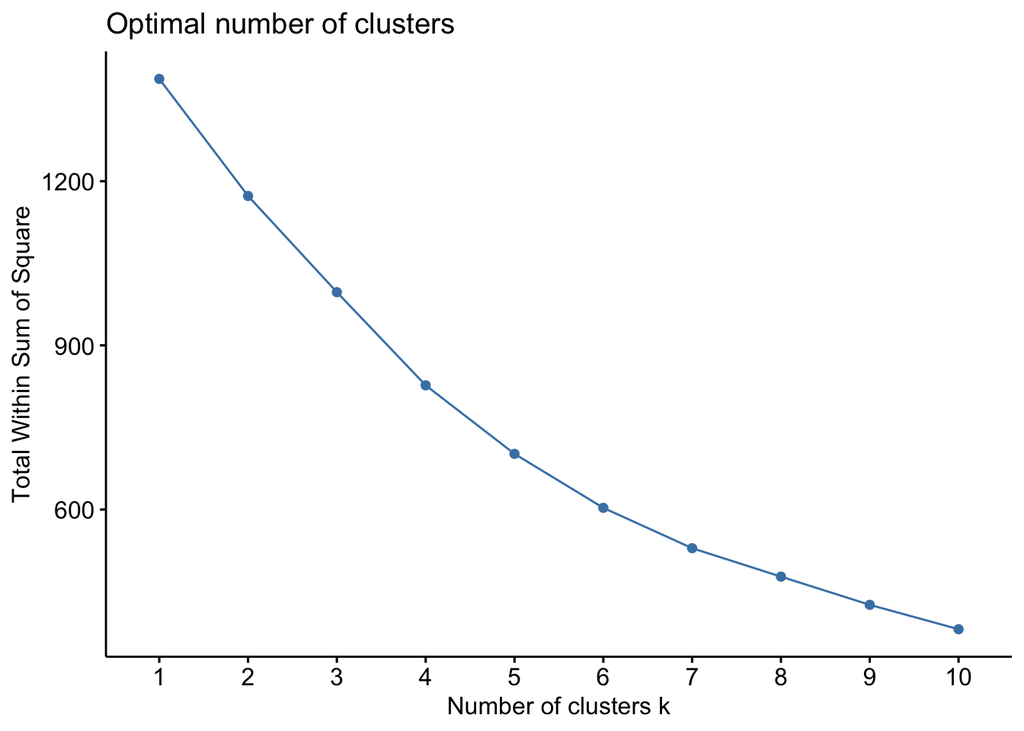

```r
fviz_nbclust(complete, FUN = hcut, method = "wss")
```

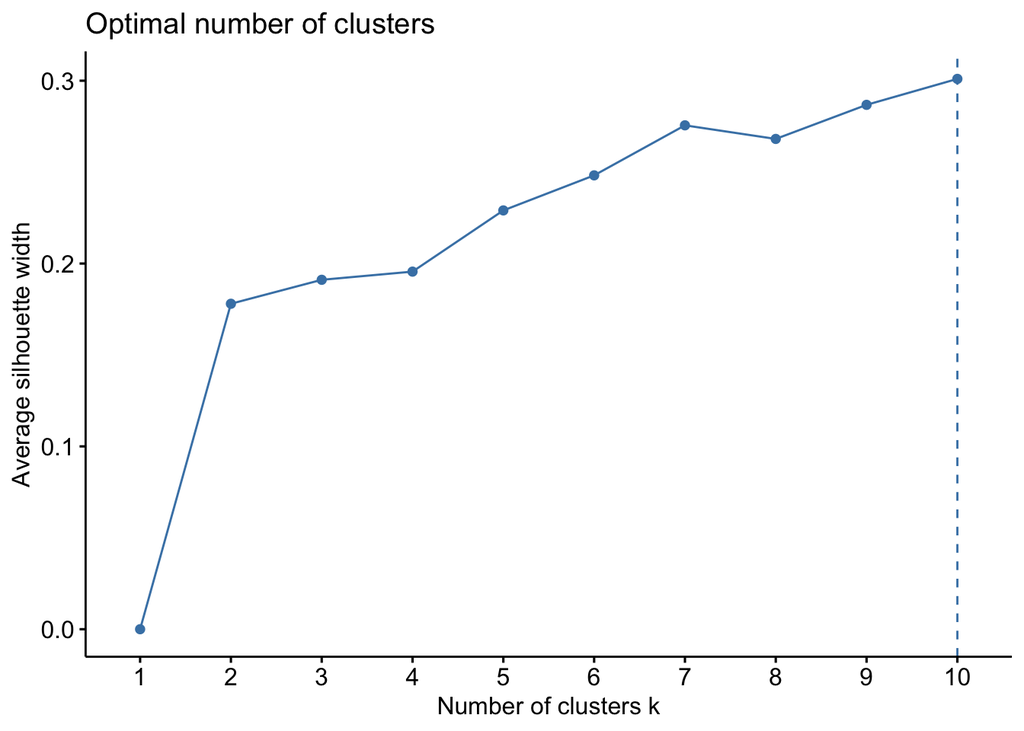

```r
fviz_nbclust(complete, FUN = hcut, method = "silhouette")
```

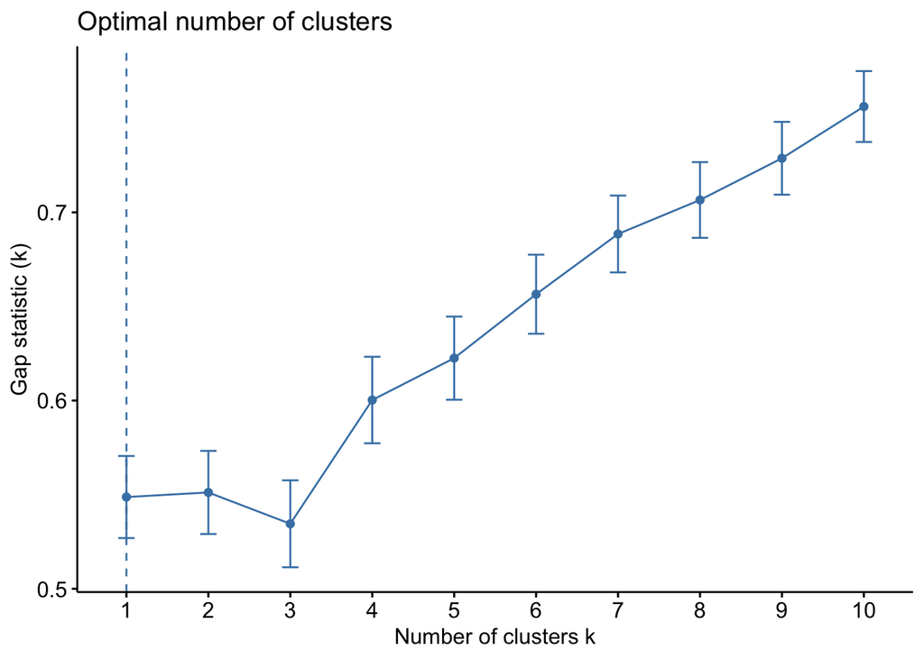

```r
fviz_nbclust(complete[, 3:19], FUN = hcut, method = "gap_stat")
```

## Cluster Assessment

```r
# Agglomerative coefficient with Agnes.
m <- c( "average", "single", "complete", "ward")
names(m) <- c( "average", "single", "complete", "ward")

# function to compute coefficient
ac <- function(x) {
  agnes(d, method = x)$ac
}

map_dbl(m, ac)
```

```
##   average    single  complete      ward
## 0.8537251 0.8541325 0.8667622 0.8942190
```